# IE 582 Statistical Learning for Data Mining

## Homework 2

**Date:** *14-12-2024*  
**School Number:** *2023072075*  
**Name:** *Yusuf Sina Öztürk*

#### Setup

- Need to import all libraries where I will use each of in different part of the homework.
- Read provided dataset.

```python
import numpy as np
import pandas as pd

import matplotlib.pyplot as plt
import math

import scipy.stats as stats
import seaborn as sns

import json
from ydata_profiling import ProfileReport
from ydata_profiling.utils.cache import cache_file

from sklearn.linear_model import LinearRegression
from sklearn.preprocessing import PolynomialFeatures, label_binarize
from sklearn.model_selection import train_test_split
from sklearn.metrics import mean_squared_error, r2_score, accuracy_score, roc_auc_score

import xgboost as xgb
import lightgbm as lgb
```

```python
match_data = pd.read_csv('match_data.csv')
```

#### Preparation of Data

- First thing first should be deletion of the rows that shouldn't be used in any anaylsis or training set. `suspended` and `stopped` columns in the set shows us which columns are not usable.
  - For this reason we should get rid of 7.8k rows that has `suspended` and 4.1k rows that has `stopped` status.
  - After that we got final of 56.1 rows

```python
len(match_data[match_data["suspended"]])
```

```
7817
```

```python
len(match_data[match_data["stopped"] == True])
```

```
4115
```

```python
match_data = match_data[(match_data['stopped'] == False) & (match_data['suspended'] == False)]
match_data = match_data.drop(columns=['stopped', 'suspended'])
len(match_data)
```

```
56127
```

#### Explatory Data Analysis

- In order to chech what is the properties of my dataset, I have used compact `ydata_profiling` library to check each column of my set with respect to their statistical values.
- The function that used below created an HTML file, it is also included in repository.

```python
%%time
report = ProfileReport(match_data, title="HW2_EDA", minimal=True)
report.to_file("HW2_EDA.html")
```

```
CPU times: user 1min 1s, sys: 35.6 s, total: 1min 36s
Wall time: 36.5 s
```

- There is `ticking` named feature on dataset which is constant in all set. Also this unuseful feature is dropped.

```python
match_data = match_data.drop(columns=['ticking'])
```

- With EDA, we also captured with high percentage zero warning and missing values warning occured in dataset.
  - For missing values we should do imputation with linear interpolation.
  - For zero values, I will check whether this zero is from start of the match or it is missinformation, for misinformed values i need to apply also linear interpolation.
    - After checking all distributions and some of the instances there is no misinformation on zero valued instances.
  - Percentage features has close to normal distribution, and seems there are misinformed values because 0 and 100 % are not fitted well on the histogram.
    - Figured that out those are clearly the firts seconds of the match. That is why it is alright to keep it like that.
  - For text features I applied apply one-code encoding to make them binary, to let ML models learn a bit better.
    - Only `name` feature of the oppenent teams are not encoded because it is more like the same as `fixture_id`. If we try to apply league based different models, or add league dimension into dataset, we could apply it on those sophisticated attemps .

```python
# In order to sort data set, need to convert types Date Time features
datetime_columns = ['current_time', 'half_start_datetime', 'match_start_datetime', 'latest_bookmaker_update']
match_data[datetime_columns] = match_data[datetime_columns].apply(pd.to_datetime)

match_data = match_data.sort_values(by=['fixture_id', 'halftime', 'current_time']).reset_index(drop=True)
```

```python
# Group features that should implemented different type of imputations
# Features that needs to impute
missing_features = match_data.columns[match_data.isnull().any()].tolist()

percentage_features = [
    "Successful Passes Percentage - away",
    "Successful Passes Percentage - home",
    "Ball Possession % - away",
    "Ball Possession % - home"
]
text_feature = ["current_state"]

integer_missing_features = set(missing_features) - set(percentage_features + text_feature)
```

```python
# Imputed Version of Dataset
match_data_imputed = match_data.copy()
```

```python
# Imputation for Integer Type Features
for fixture_id, group in match_data.groupby('fixture_id'):
    group = group.sort_values('current_time')

    for feature in integer_missing_features:
        missing_indices = group[group[feature].isna()].index

        for idx in missing_indices:
            valid_before = group.loc[:idx, feature].dropna()
            lower_bound = valid_before.iloc[-1] if not valid_before.empty else pd.NA
            lower_time = group.loc[valid_before.index[-1], 'current_time'] if not valid_before.empty else group.loc[idx, 'current_time']

            valid_after = group.loc[idx:, feature].dropna()
            upper_bound = valid_after.iloc[0] if not valid_after.empty else pd.NA
            upper_time = group.loc[valid_after.index[0], 'current_time'] if not valid_after.empty else group.loc[idx, 'current_time']

            if pd.isna(group.at[idx, feature]):
                if pd.isna(lower_bound) == True & pd.isna(upper_bound) == True:
                    continue
                elif pd.isna(lower_bound):
                    group.at[idx, feature] = 0
                elif pd.isna(upper_bound):
                    group.at[idx, feature] = lower_bound
                else:
                    time_diff = (upper_time - lower_time).total_seconds()
                    value_diff = upper_bound - lower_bound
                    time_diff_missing = (group.loc[idx, 'current_time'] - lower_time).total_seconds()
                    interpolated_value = lower_bound + (value_diff * time_diff_missing / time_diff)
                    group.at[idx, feature] = interpolated_value
        match_data_imputed.loc[group.index, feature] = group[feature]
```

```python
# Rounding after linear interpolation
match_data_imputed[list(integer_missing_features)] = match_data_imputed[list(integer_missing_features)].round(0)
```

```python
# Imputation for Float Type Features
for fixture_id, group in match_data.groupby('fixture_id'):
    group = group.sort_values('current_time')

    for feature in percentage_features:
        missing_indices = group[group[feature].isna()].index
        for idx in missing_indices:
            valid_before = group.loc[:idx, feature].dropna()
            lower_bound = valid_before.iloc[-1] if not valid_before.empty else pd.NA
            lower_time = group.loc[valid_before.index[-1], 'current_time'] if not valid_before.empty else group.loc[idx, 'current_time']

            valid_after = group.loc[idx:, feature].dropna()
            upper_bound = valid_after.iloc[0] if not valid_after.empty else pd.NA
            upper_time = group.loc[valid_after.index[0], 'current_time'] if not valid_after.empty else group.loc[idx, 'current_time']

            if pd.isna(group.at[idx, feature]):
                if pd.isna(lower_bound) == True & pd.isna(upper_bound) == True:
                    continue
                elif pd.isna(lower_bound) == True & pd.isna(upper_bound) == True:
                    group.at[idx, feature] = 0
                elif pd.isna(lower_bound) and not pd.isna(upper_bound):
                    group.at[idx, feature] = upper_bound
                elif pd.isna(upper_bound):

                    group.at[idx, feature] = lower_bound
                else:

                    time_diff = (upper_time - lower_time).total_seconds()
                    value_diff = upper_bound - lower_bound
                    time_diff_missing = (group.loc[idx, 'current_time'] - lower_time).total_seconds()
                    interpolated_value = lower_bound + (value_diff * time_diff_missing / time_diff)
                    group.at[idx, feature] = interpolated_value
        match_data_imputed.loc[group.index, feature] = group[feature]
```

```python
# Imputation for Text Type Features
for fixture_id, group in match_data.groupby('fixture_id'):
    group = group.sort_values('current_time')

    for feature in text_feature:
        missing_indices = group[group[feature].isna()].index
        for idx in missing_indices:
            valid_before = group.loc[:idx, feature].dropna()
            lower_bound = valid_before.iloc[-1] if not valid_before.empty else pd.NA
            lower_time = group.loc[valid_before.index[-1], 'current_time'] if not valid_before.empty else group.loc[idx, 'current_time']

            valid_after = group.loc[idx:, feature].dropna()
            upper_bound = valid_after.iloc[0] if not valid_after.empty else pd.NA
            upper_time = group.loc[valid_after.index[0], 'current_time'] if not valid_after.empty else group.loc[idx, 'current_time']

            if pd.isna(group.at[idx, feature]):
                if pd.isna(lower_bound):
                    group.at[idx, feature] = "X"
                elif pd.isna(upper_bound):
                    group.at[idx, feature] = lower_bound
                else:
                    group.at[idx, feature] = "X"
        match_data_imputed.loc[group.index, feature] = group[feature]
```

```python
match_data_imputed.to_csv('match_data_imputed.csv', index=False)
```

```python
match_data_imputed = pd.read_csv('match_data_imputed.csv')
```

- Now, dataset is ready to do analysis and training ML models.

#### Task 1

##### Part 1

```python
match_data_imputed['p_home'] = 1 / match_data_imputed['1']
match_data_imputed['p_away'] = 1 / match_data_imputed['2']
match_data_imputed['p_tie'] = 1 / match_data_imputed['X']
```

##### Part 2

```python
match_data_imputed['p_home_norm'] = match_data_imputed['p_home'] / (match_data_imputed['p_home'] + match_data_imputed['p_away'] + match_data_imputed['p_tie'])
match_data_imputed['p_away_norm'] = match_data_imputed['p_away'] / (match_data_imputed['p_home'] + match_data_imputed['p_away'] + match_data_imputed['p_tie'])
match_data_imputed['p_tie_norm'] = match_data_imputed['p_tie'] / (match_data_imputed['p_home'] + match_data_imputed['p_away'] + match_data_imputed['p_tie'])
```

```python
match_data_imputed[["1", "2", "X", "p_home", "p_away","p_tie", "p_home_norm", "p_away_norm","p_tie_norm"]].head(5)
```

|  | 1 | 2 | X | p_home | p_away | p_tie | p_home_norm | p_away_norm | p_tie_norm |
| --- | --- | --- | --- | --- | --- | --- | --- | --- | --- |
| 0 | 1.66 | 5.0 | 4.0 | 0.602410 | 0.200000 | 0.25 | 0.572410 | 0.190040 | 0.237550 |
| 1 | 1.66 | 5.0 | 4.0 | 0.602410 | 0.200000 | 0.25 | 0.572410 | 0.190040 | 0.237550 |
| 2 | 1.61 | 5.5 | 4.0 | 0.621118 | 0.181818 | 0.25 | 0.589891 | 0.172677 | 0.237431 |
| 3 | 1.61 | 5.0 | 4.0 | 0.621118 | 0.200000 | 0.25 | 0.579878 | 0.186721 | 0.233401 |
| 4 | 1.61 | 5.0 | 4.0 | 0.621118 | 0.200000 | 0.25 | 0.579878 | 0.186721 | 0.233401 |

##### Part 3 & 4

```python
match_data_imputed['p_home_min_away'] = match_data_imputed['p_home'] - match_data_imputed['p_away']
match_data_imputed['p_home_min_away_norm'] = match_data_imputed['p_home_norm'] - match_data_imputed['p_away_norm']
```

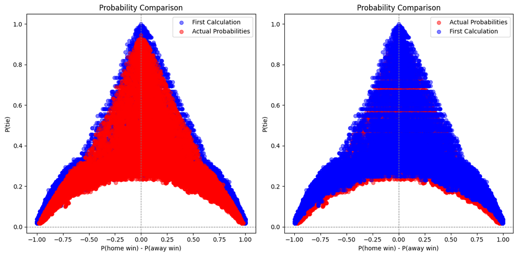

```python
plt.figure(figsize=(12, 6))

plt.subplot(1, 2, 1)
plt.scatter(match_data_imputed['p_home_min_away'], match_data_imputed['p_tie'], color='blue', label='First Calculation', alpha=0.5)
plt.scatter(match_data_imputed['p_home_min_away_norm'], match_data_imputed['p_tie_norm'], color='red', label='Actual Probabilities', alpha=0.5)

plt.xlabel('P(home win) - P(away win)')
plt.ylabel('P(tie)')
plt.title('Probability Comparison')
plt.axhline(0, color='gray', linestyle='--', linewidth=0.8)
plt.axvline(0, color='gray', linestyle='--', linewidth=0.8)
plt.legend()

plt.subplot(1, 2, 2)
plt.scatter(match_data_imputed['p_home_min_away_norm'], match_data_imputed['p_tie_norm'], color='red', label='Actual Probabilities', alpha=0.5)
plt.scatter(match_data_imputed['p_home_min_away'], match_data_imputed['p_tie'], color='blue', label='First Calculation', alpha=0.5)

plt.xlabel('P(home win) - P(away win)')
plt.ylabel('P(tie)')
plt.title('Probability Comparison')
plt.axhline(0, color='gray', linestyle='--', linewidth=0.8)
plt.axvline(0, color='gray', linestyle='--', linewidth=0.8)
plt.legend()

plt.tight_layout()
plt.show()
```

- As it can see from the. scatter plot, because first calculation of odds has profit margin of bookmaker, it has slightly higher odds.
- Red dots are actual odds of match result.

```python
num_bins = 100
match_data_imputed['bin'] = pd.qcut(match_data_imputed['p_home_min_away'], q=num_bins)
match_data_imputed['bin_norm'] = pd.qcut(match_data_imputed['p_home_min_away_norm'], q=num_bins)

bin_stats = match_data_imputed.groupby('bin').agg(
    total_games=('p_tie', 'size'),
    total_draws=('result', lambda x: (x == "X").sum())
)
bin_stats['draw_probability'] = bin_stats['total_draws'] / bin_stats['total_games']

norm_bin_stats = match_data_imputed.groupby('bin_norm').agg(
    total_games=('p_tie_norm', 'size'),
    total_draws=('result', lambda x: (x == "X").sum())
)
norm_bin_stats['draw_probability'] = norm_bin_stats['total_draws'] / norm_bin_stats['total_games']
```

```python
# Bins location on plot
bin_stats['lower_bound'] = bin_stats.index.map(lambda x: x.left)
bin_stats['upper_bound'] = bin_stats.index.map(lambda x: x.right)
bin_stats['bin_midpoint'] = (bin_stats['lower_bound'].astype(float) + bin_stats['upper_bound'].astype(float)) / 2

norm_bin_stats['lower_bound'] = norm_bin_stats.index.map(lambda x: x.left)
norm_bin_stats['upper_bound'] = norm_bin_stats.index.map(lambda x: x.right)
norm_bin_stats['bin_midpoint'] = (norm_bin_stats['lower_bound'].astype(float) + norm_bin_stats['upper_bound'].astype(float)) / 2

# Polynomial Trend Lines
## Without Normalized Probabilities
poly = PolynomialFeatures(degree=2, include_bias=False)
X_poly = poly.fit_transform(match_data_imputed[['p_home_min_away']])
model = LinearRegression()
model.fit(X_poly, match_data_imputed['p_tie'])

x_vals = np.linspace(match_data_imputed['p_home_min_away'].min(), match_data_imputed['p_home_min_away'].max(), 500)
x_vals_poly = poly.transform(x_vals.reshape(-1, 1))
trend_line = model.predict(x_vals_poly)

## With Normalized Probabilities
poly = PolynomialFeatures(degree=2, include_bias=False)
X_poly = poly.fit_transform(match_data_imputed[['p_home_min_away_norm']])
model = LinearRegression()
model.fit(X_poly, match_data_imputed['p_tie_norm'])

x_vals_norm = np.linspace(match_data_imputed['p_home_min_away_norm'].min(), match_data_imputed['p_home_min_away_norm'].max(), 500)
x_vals_poly_norm = poly.transform(x_vals_norm.reshape(-1, 1))
trend_line_norm = model.predict(x_vals_poly_norm)
```

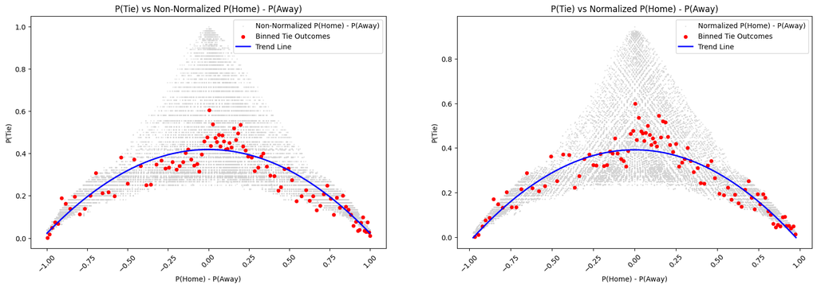

```python
plt.figure(figsize=(20, 6))

plt.subplot(1, 2, 1)
plt.scatter(match_data_imputed['p_home_min_away'], match_data_imputed['p_tie'], color='lightgray', s=1, alpha=0.5, label="Non-Normalized P(Home) - P(Away)")

plt.scatter(bin_stats['bin_midpoint'], bin_stats['draw_probability'], color='red', s=20, label='Binned Tie Outcomes')
plt.plot(x_vals, trend_line, color='blue', linewidth=2, label='Trend Line')

plt.xlabel('P(Home) - P(Away)')
plt.ylabel('P(Tie)')
plt.title('P(Tie) vs Non-Normalized P(Home) - P(Away)')
plt.xticks(rotation=45)
plt.legend()

plt.subplot(1, 2, 2)
plt.scatter(match_data_imputed['p_home_min_away_norm'], match_data_imputed['p_tie_norm'], color='lightgray', s=1, alpha=0.5, label="Normalized P(Home) - P(Away)")

plt.scatter(norm_bin_stats['bin_midpoint'], norm_bin_stats['draw_probability'], color='red', s=20, label='Binned Tie Outcomes')
plt.plot(x_vals_norm, trend_line_norm, color='blue', linewidth=2, label='Trend Line')

plt.xlabel('P(Home) - P(Away)')
plt.ylabel('P(Tie)')
plt.title('P(Tie) vs Normalized P(Home) - P(Away)')
plt.xticks(rotation=45)
plt.legend()

plt.show()
```

- As it can see from above plots, it can seen that when `P(Home) - P(Away)` value in between 0 - 0.25 then winning chance is more which means that one can make money out of with correct strategy.
- But it is correct that with the odds and actual results are biased which we clearly see the correlation between red dots and blue trend line

#### Task 2

- Filter 1: Red Card before 15th minute
- Filter 2: Goal after 90th minute
- Filter 3: 2 Score Change before 15th minute
- Filter 4: Ball Possession above 70 at the end of first half

```python
filtered_fixture_ids_list = []
```

```python
# Filter 1
filtered_data = match_data_imputed[
    (match_data_imputed['halftime'] == "1st-half") &
    (match_data_imputed['minute'] < 16) &
    ((match_data_imputed['Redcards - home'] + match_data_imputed['Redcards - away']) > 0)
][['fixture_id', 'halftime', 'minute', 'Redcards - home', 'Redcards - away']]

filtered_fixture_ids_list.extend(list(filtered_data['fixture_id'].unique()))
len(list(filtered_data['fixture_id'].unique()))
```

```
2
```

```python
# Filter 2
filtered_data = match_data_imputed[
    (match_data_imputed['halftime'] == "2nd-half") &
    (match_data_imputed['minute'] > 44) &
    ((match_data_imputed['Goals - home'] + match_data_imputed['Goals - away']) > 0)
][['fixture_id', 'halftime', 'minute', 'Redcards - home', 'Redcards - away']]
filtered_fixture_ids_list.extend(list(filtered_data['fixture_id'].unique()))
len(list(filtered_data['fixture_id'].unique()))
```

```
426
```

```python
# Filter 3
filtered_data = match_data_imputed[
    (match_data_imputed['halftime'] == "1st-half") &
    (match_data_imputed['minute'] < 16) &
    ((match_data_imputed['Goals - home'] + match_data_imputed['Goals - away']) > 0)
][['fixture_id', 'halftime', 'minute', 'Redcards - home', 'Redcards - away']]
filtered_fixture_ids_list.extend(list(filtered_data['fixture_id'].unique()))
len(list(filtered_data['fixture_id'].unique()))
```

```
187
```

```python
# Filter 4
filtered_data = match_data_imputed[
    (match_data_imputed['halftime'] == "1st-half") &
    (match_data_imputed['minute'] > 40) &
    ((match_data_imputed['Ball Possession % - home'] > 69) | (match_data_imputed['Ball Possession % - away'] > 69))
][['fixture_id', 'halftime', 'minute', 'Ball Possession % - home', 'Ball Possession % - away']]
filtered_fixture_ids_list.extend(list(filtered_data['fixture_id'].unique()))
len(list(filtered_data['fixture_id'].unique()))
```

```
96
```

```python
filtered_fixture_ids_unique_list = list(set(filtered_fixture_ids_list))
```

```python
len(filtered_fixture_ids_unique_list)
```

```
511
```

```python
filtered_data = match_data_imputed[~match_data_imputed['fixture_id'].isin(filtered_fixture_ids_unique_list)]
```

```python
len(filtered_data['fixture_id'].unique())
```

```
137
```

```python
len(match_data_imputed['fixture_id'].unique())
```

```
648
```

- Filter 1: Red Card before 15th minute
  - 2 matches excluded because of this abnormal statistics
- Filter 2: Goal after 90th minute
  - 426 matches excluded because of this abnormal statistics
- Filter 3: 2 Score Change before 15th minute
  - 187 matches excluded because of this abnormal statistics
- Filter 4: Ball Possession above 70 at the end of first half
  - 96 matches excluded because of this abnormal statistics

Without outlier elimination there was total of 648 matches.

Total distinct matches that are filtered from our set is 511.

Now there is only 137 matches that are statisticaly stable

##### Part 2 (Repeated Task 1)

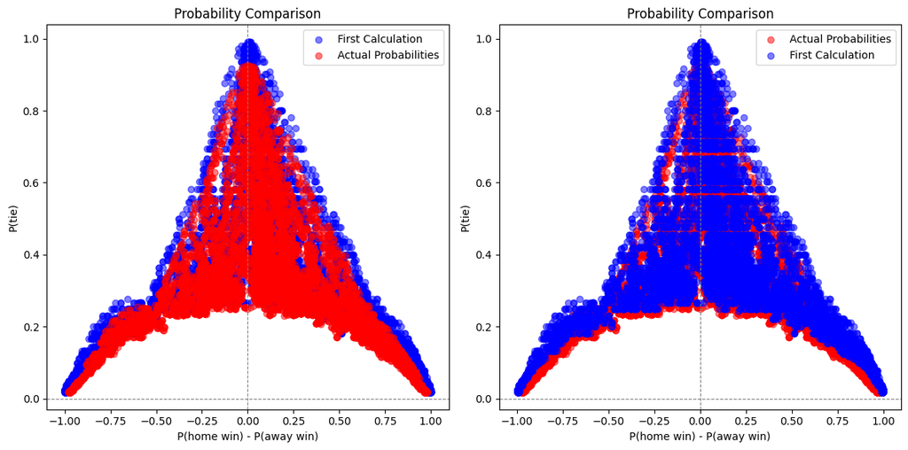

```python
plt.figure(figsize=(12, 6))

plt.subplot(1, 2, 1)
plt.scatter(filtered_data['p_home_min_away'], filtered_data['p_tie'], color='blue', label='First Calculation', alpha=0.5)
plt.scatter(filtered_data['p_home_min_away_norm'], filtered_data['p_tie_norm'], color='red', label='Actual Probabilities', alpha=0.5)

plt.xlabel('P(home win) - P(away win)')
plt.ylabel('P(tie)')
plt.title('Probability Comparison')
plt.axhline(0, color='gray', linestyle='--', linewidth=0.8)
plt.axvline(0, color='gray', linestyle='--', linewidth=0.8)
plt.legend()

plt.subplot(1, 2, 2)
plt.scatter(filtered_data['p_home_min_away_norm'], filtered_data['p_tie_norm'], color='red', label='Actual Probabilities', alpha=0.5)
plt.scatter(filtered_data['p_home_min_away'], filtered_data['p_tie'], color='blue', label='First Calculation', alpha=0.5)

plt.xlabel('P(home win) - P(away win)')
plt.ylabel('P(tie)')
plt.title('Probability Comparison')
plt.axhline(0, color='gray', linestyle='--', linewidth=0.8)
plt.axvline(0, color='gray', linestyle='--', linewidth=0.8)
plt.legend()

plt.tight_layout()
plt.show()
```

- Without outliers, because of there are little dat left, we can see that included bookmaker's margin probabilitires higher with some coefficient

```python
num_bins = 21
filtered_data['bin'] = pd.qcut(filtered_data['p_home_min_away'], q=num_bins)
filtered_data['bin_norm'] = pd.qcut(filtered_data['p_home_min_away_norm'], q=num_bins)

filtered_bin_stats = filtered_data.groupby('bin').agg(
    total_games=('p_tie', 'size'),
    total_draws=('result', lambda x: (x == "X").sum())
)
filtered_bin_stats['draw_probability'] = filtered_bin_stats['total_draws'] / filtered_bin_stats['total_games']

filtered_norm_bin_stats = filtered_data.groupby('bin_norm').agg(
    total_games=('p_tie_norm', 'size'),
    total_draws=('result', lambda x: (x == "X").sum())
)
filtered_norm_bin_stats['draw_probability'] = filtered_norm_bin_stats['total_draws'] / filtered_norm_bin_stats['total_games']
```

```python
# Bins location on plot
filtered_bin_stats['lower_bound'] = filtered_bin_stats.index.map(lambda x: x.left)
filtered_bin_stats['upper_bound'] = filtered_bin_stats.index.map(lambda x: x.right)
filtered_bin_stats['bin_midpoint'] = (filtered_bin_stats['lower_bound'].astype(float) + filtered_bin_stats['upper_bound'].astype(float)) / 2

filtered_norm_bin_stats['lower_bound'] = filtered_norm_bin_stats.index.map(lambda x: x.left)
filtered_norm_bin_stats['upper_bound'] = filtered_norm_bin_stats.index.map(lambda x: x.right)
filtered_norm_bin_stats['bin_midpoint'] = (filtered_norm_bin_stats['lower_bound'].astype(float) + filtered_norm_bin_stats['upper_bound'].astype(float)) / 2

# Polynomial Trend Lines
## Without Normalized Probabilities
poly = PolynomialFeatures(degree=2, include_bias=False)
X_poly = poly.fit_transform(filtered_data[['p_home_min_away']])
model = LinearRegression()
model.fit(X_poly, filtered_data['p_tie'])

filtered_x_vals = np.linspace(filtered_data['p_home_min_away'].min(), filtered_data['p_home_min_away'].max(), 500)
filtered_x_vals_poly = poly.transform(filtered_x_vals.reshape(-1, 1))
filtered_trend_line = model.predict(filtered_x_vals_poly)

## With Normalized Probabilities
poly = PolynomialFeatures(degree=2, include_bias=False)
X_poly = poly.fit_transform(filtered_data[['p_home_min_away_norm']])
model = LinearRegression()
model.fit(X_poly, filtered_data['p_tie_norm'])

filtered_x_vals_norm = np.linspace(filtered_data['p_home_min_away_norm'].min(), filtered_data['p_home_min_away_norm'].max(), 500)
filtered_x_vals_poly_norm = poly.transform(filtered_x_vals_norm.reshape(-1, 1))
filtered_trend_line_norm = model.predict(filtered_x_vals_poly_norm)
```

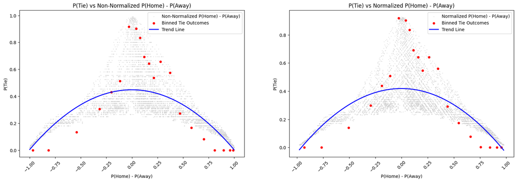

```python
plt.figure(figsize=(20, 6))

plt.subplot(1, 2, 1)
plt.scatter(filtered_data['p_home_min_away'], filtered_data['p_tie'], color='lightgray', s=1, alpha=0.5, label="Non-Normalized P(Home) - P(Away)")

plt.scatter(filtered_bin_stats['bin_midpoint'], filtered_bin_stats['draw_probability'], color='red', s=20, label='Binned Tie Outcomes')
plt.plot(filtered_x_vals, filtered_trend_line, color='blue', linewidth=2, label='Trend Line')

plt.xlabel('P(Home) - P(Away)')
plt.ylabel('P(Tie)')
plt.title('P(Tie) vs Non-Normalized P(Home) - P(Away)')
plt.xticks(rotation=45)
plt.legend()

plt.subplot(1, 2, 2)
plt.scatter(filtered_data['p_home_min_away_norm'], filtered_data['p_tie_norm'], color='lightgray', s=1, alpha=0.5, label="Normalized P(Home) - P(Away)")

plt.scatter(filtered_norm_bin_stats['bin_midpoint'], filtered_norm_bin_stats['draw_probability'], color='red', s=20, label='Binned Tie Outcomes')
plt.plot(filtered_x_vals_norm, filtered_trend_line_norm, color='blue', linewidth=2, label='Trend Line')

plt.xlabel('P(Home) - P(Away)')
plt.ylabel('P(Tie)')
plt.title('P(Tie) vs Normalized P(Home) - P(Away)')
plt.xticks(rotation=45)
plt.legend()

plt.show()
```

- Because filtered a lot of data, need to decrease also bin count to compare both results on the same page.
- Now the plot is completely changed. When `P(Home) - P(Away)` value is closer to the 0, market inefficiency clearly can seen on the difference between red dots and blue trend line.
  - While actual probability (historic statistics) are almost close to the 1 when `P(Home) - P(Away)` difference is close to 0. Market inefficiency can clearly seen here.
  - If correct matches that has high probability of nothing special thing happen choosen, and if `P(Home)` and `P(Away)` probabilites are closer to each other, then there is a chance to gain some cash.

Results are completely different after filtering outlier instances, with checking odds bias it can clearly seen.

#### Task 3

#### Model Structure and Training Strategy

- I choose my decision tree model struce as LightGBM which is one of the boosting tree structure that has some advantages on fast training
- Models will be trained are multiclass classification with `result` column target
- There is two dataset, `filtered` and `imputed`
  - If models can't achive enough performance, then we can be do outlier elimination and train our models with `filtered` dataset.
- Bookmaker odd probabilties or normalized probabities will be taken and not taken on different trainings because these features could cause leakage

##### Feature Preparation

- Need to get rid of features that are not needed
  - Time features
    - `halftime` and `minute` will be enough for this problem
  - We don't need bookmaker information for this model
  - We can apply team based prediction
    - However, this dataset includes more league than one, it is better to not use team related features and its information in order to avoid high-cardinality
  - `bins` for task 1 and 2 does not needed here
- Need to encode these features
  - `halftime`
  - `current_state`

```python
# Feature Manipulation for Whole Set
# Delete unnecessary columns
training_data = match_data_imputed.copy()

unnecessary_columns = [
    'fixture_id',
    'current_time',
    'half_start_datetime',
    'match_start_datetime',
    'second',
    'latest_bookmaker_update',
    'name',
    'final_score',
    '1',
    '2',
    'X',
    'bin',
    'bin_norm'
]
training_data.drop(unnecessary_columns, axis='columns', inplace=True)

# One-Hot Encoding
training_data = pd.get_dummies(training_data, columns=["halftime"], prefix = "hf")
training_data = pd.get_dummies(training_data, columns=["current_state"], prefix = "current_state")

# Target Mapping
label_mapping = {"X": 0, "1": 1, "2": 2}
reverse_label_mapping = {v: k for k, v in label_mapping.items()}
training_data['target'] = [label_mapping[label] for label in training_data['result']]
training_data.drop(['result'], axis='columns', inplace=True)


# Features that can cause Leakage (Later dropped from training set)
can_cause_leakage_feats = [
    'p_home_norm',
    'p_away_norm',
    'p_tie_norm',
    'p_home',
    'p_away',
    'p_tie',
    'p_home_min_away',
    'p_home_min_away_norm'
]
```

##### Tree 1

- Used whole set
- Included probabilities from bookmaker

```python
# Separate features and target
X = training_data.drop(columns=['target'])
y = training_data['target']

# Train-Test Split
X_train, X_temp, y_train, y_temp = train_test_split(X, y, test_size=0.3, random_state=42, stratify=y)
X_val, X_test, y_val, y_test = train_test_split(X_temp, y_temp, test_size=0.5, random_state=42, stratify=y_temp)
```

```python
lgb_model = lgb.LGBMClassifier(

    objective = 'multiclass',
    n_jobs = -1,
    random_state = 42,
    metric = "multi_logloss",
    verbose = 0,
    boosting_type='gbdt',

    n_estimators = 20000,
    learning_rate = 0.06,
    max_depth = 7,
    reg_alpha = 0.8118182698995919,
    reg_lambda = 0.011416912404479432,
    colsample_bytree = 0.15,
    subsample = 0.95,
    num_leaves = 5,
    min_child_samples = 364
)
lgb_model.fit(
    X=X_train,
    y=y_train,
    eval_set=[(X_val, y_val)],
    eval_metric= "multi_logloss",
    callbacks=[lgb.early_stopping(stopping_rounds=50),lgb.log_evaluation(1)]
)
```

```python
# Predict on train and test data
y_train_pred = lgb_model.predict_proba(X_train)
y_test_pred = lgb_model.predict_proba(X_test)

# Convert probabilities to class labels
y_train_pred_classes = y_train_pred.argmax(axis=1)
y_test_pred_classes = y_test_pred.argmax(axis=1)

# Calculate accuracies
train_accuracy = accuracy_score(y_train, y_train_pred_classes)
test_accuracy = accuracy_score(y_test, y_test_pred_classes)

print(f"Train Accuracy: {train_accuracy:.2f}")
print(f"Test Accuracy: {test_accuracy:.2f}")
```

```
Train Accuracy: 1.00
Test Accuracy: 0.99
```

```python
# Binarize labels for AUC calculation
classes = sorted(y_test.unique())  # Ensure consistent class order
y_test_bin = label_binarize(y_test, classes=classes)

# Predict probabilities
y_test_pred = lgb_model.predict_proba(X_test)

# Calculate multiclass AUC
test_auc = roc_auc_score(y_test_bin, y_test_pred, multi_class='ovr')
print(f"Test Set AUC: {test_auc:.2f}")
```

```
Test Set AUC: 1.00
```

```python
# AUC per class
for i, class_label in enumerate(classes):
    test_auc_class = roc_auc_score(y_test_bin[:, i], y_test_pred[:, i])
    print(f"Class {class_label} Test AUC: {test_auc_class:.2f}")
```

```
Class 0 Test AUC: 1.00
Class 1 Test AUC: 1.00
Class 2 Test AUC: 1.00
```

```python
# Feature Importances
feature_importance = lgb_model.feature_importances_
feature_names = X_train.columns if hasattr(X_train, 'columns') else [f'Feature {i}' for i in range(X_train.shape[1])]

# Create a DataFrame to pair feature names with their importance
importance_df = pd.DataFrame({
    'Feature': feature_names,
    'Importance': feature_importance
})

importance_df = importance_df.sort_values(by='Importance', ascending=False)
importance_df.head(10)
```

|  | Feature | Importance |
| --- | --- | --- |
| 95 | p_home_min_away | 6068 |
| 93 | p_away_norm | 5710 |
| 94 | p_tie_norm | 4988 |
| 92 | p_home_norm | 4732 |
| 77 | Successful Passes Percentage - away | 4626 |
| 78 | Successful Passes Percentage - home | 4620 |
| 10 | Ball Safe - home | 4266 |
| 9 | Ball Safe - away | 4095 |
| 8 | Ball Possession % - home | 3691 |
| 96 | p_home_min_away_norm | 3570 |

- As it seen on performance metrics;
  - The model work perfect even the data is not filtered.
  - There could be leakage with using probabilities that we get from bookmaker
    - However, we are doing live betting, we already have these kind of information while doing inference. Even if it gives a lot of information into model, it is alright because we can reach that information

##### Tree 2

- Used whole set
- Drpped probabilities from bookmaker

```python
# Get rid of Bookmaker Probabilities
wo_p_training_data = training_data.copy()
wo_p_training_data.drop(can_cause_leakage_feats, axis='columns', inplace=True)

# Separate features and target
X_wo_p = wo_p_training_data.drop(columns=['target'])
y_wo_p = wo_p_training_data['target']

# Train-Test Split
X_train, X_temp, y_train, y_temp = train_test_split(X_wo_p, y_wo_p, test_size=0.3, random_state=42, stratify=y)
X_val, X_test, y_val, y_test = train_test_split(X_temp, y_temp, test_size=0.5, random_state=42, stratify=y_temp)
```

```python
wo_p_lgb_model = lgb.LGBMClassifier(

    objective = 'multiclass',
    n_jobs = -1,
    random_state = 42,
    metric = "multi_logloss",
    verbose = 0,
    boosting_type='gbdt',

    n_estimators = 20000,
    learning_rate = 0.05,
    max_depth = 7,
    reg_alpha = 0.8118182698995919,
    reg_lambda = 0.011416912404479432,
    colsample_bytree = 0.15,
    subsample = 0.95,
    num_leaves = 5,
    min_child_samples = 364
)
wo_p_lgb_model.fit(
    X=X_train,
    y=y_train,
    eval_set=[(X_val, y_val)],
    eval_metric= "multi_logloss",
    callbacks=[lgb.early_stopping(stopping_rounds=50),lgb.log_evaluation(1)]
)
```

```python
# Predictions
y_train_pred = wo_p_lgb_model.predict_proba(X_train)
y_test_pred = wo_p_lgb_model.predict_proba(X_test)

# Convert probabilities to class labels
y_train_pred_classes = y_train_pred.argmax(axis=1)
y_test_pred_classes = y_test_pred.argmax(axis=1)

# Perfomances
train_accuracy = accuracy_score(y_train, y_train_pred_classes)
test_accuracy = accuracy_score(y_test, y_test_pred_classes)

print(f"Train Accuracy: {train_accuracy:.2f}")
print(f"Test Accuracy: {test_accuracy:.2f}")
```

```
Train Accuracy: 1.00
Test Accuracy: 0.98
```

```python
# Binarize labels for AUC calculation
classes = sorted(y_test.unique())
y_test_bin = label_binarize(y_test, classes=classes)

# Multiclass AUC
test_auc = roc_auc_score(y_test_bin, y_test_pred, multi_class='ovr')
print(f"Test Set AUC: {test_auc:.2f}")
```

```
Test Set AUC: 1.00
```

```python
# AUC per class
for i, class_label in enumerate(classes):
    test_auc_class = roc_auc_score(y_test_bin[:, i], y_test_pred[:, i])
    print(f"Class {class_label} Test AUC: {test_auc_class:.2f}")
```

```
Class 0 Test AUC: 1.00
Class 1 Test AUC: 1.00
Class 2 Test AUC: 1.00
```

```python
# Feature Importances
feature_importance = wo_p_lgb_model.feature_importances_
feature_names = X_train.columns if hasattr(X_train, 'columns') else [f'Feature {i}' for i in range(X_train.shape[1])]

importance_df = pd.DataFrame({
    'Feature': feature_names,
    'Importance': feature_importance
})

importance_df = importance_df.sort_values(by='Importance', ascending=False)
importance_df.head(10)
```

|  | Feature | Importance |
| --- | --- | --- |
| 78 | Successful Passes Percentage - home | 10477 |
| 8 | Ball Possession % - home | 10365 |
| 10 | Ball Safe - home | 9324 |
| 76 | Successful Passes - home | 8016 |
| 46 | Passes - home | 6542 |
| 77 | Successful Passes Percentage - away | 6078 |
| 42 | Long Passes - home | 6060 |
| 6 | Attacks - home | 5911 |
| 32 | Headers - home | 5532 |
| 18 | Dangerous Attacks - home | 5307 |

- Evenif, this model is not using bookmaker probabilities, with provided feature set, it can do predictions almost perfect.
- It means that someone who bets on online/live betting, he can use provided LightGBM model to get predictions, and do his bets accordingly and make some money from it.
  - However, we are not always be sure about this situation. It should be checked on different and bigger dataset.

##### Model Prediction Probabilities vs Bookmaker Odd Probabilities

- On model 1, bookmaker probabilities are also used as features and they are the top important features as we seen on feature importance table of model 1.
  - This means that while doing prediction of match result, bookmaker probabilities includes important information, but is it inefficient?
- We will compare model predictions with bookmakers probabilites for each class.

```python
y_test_bookmaker = X_test[['p_tie', 'p_home', 'p_away']].to_numpy()
```

```python
# Calculate Mean Squared Error
mse = np.mean((y_test_pred - y_test_bookmaker) ** 2, axis=1)

# Calculate KL Divergence
kl_divergence = np.sum(y_test_bookmaker * np.log(y_test_bookmaker / (y_test_pred + 1e-10)), axis=1)

# Analyze deviations
deviation_analysis = pd.DataFrame({
    'MSE': mse,
    'KL Divergence': kl_divergence
})
```

```python
len(y_test_pred)
```

```
8420
```

```python
# Check for significant deviations (MSE > 0.05)
len(deviation_analysis[deviation_analysis['MSE'] > 0.05])
```

```
5164
```

```python
deviation_analysis['KL Divergence'].quantile([0.01, 0.1, 0.25, 0.5, 0.75])
```

```
0.01    0.084061
0.10    0.348772
0.25    0.763069
0.50    1.759085
0.75    3.018599
Name: KL Divergence, dtype: float64
```

- As we can see from the deviation between model predictions and bookmaker probabilities;
  - There are total of 8.4k instance in test set and with respect to MSE greater than 5% is 60% which relatively means predictions are deviated from bookmaker prediction most of the time.
  - Also if we check Kullback-Leibler (KL) Divergence measure used to quantify the difference between two probability distributions. If this divergence value close to 0 then probabilities does not deviate too much. However, when we check the quantiles of KL Divergence values even first quantile it is not close to 0.